# Module 3 Assignment — Multiple Linear Regression Modeling

Rahul Jadhav

1/30/2022

```r
main_dataset <- read.csv("AmesHousing.csv")
```

## INTRODUCTION

In this assignment we are to build Multiple Linear regression model for predicting Sale Price of houses in Ames. Sale Price is response variable we will use highest and lowest correlation variable we found using correlation assignment. We are also going to estimate a linear regression model, learn to interpret results of the module, and evaluate the fitted model.

## MODELS

We developed 2 model, one with variables having highest correlation and one with variables having lowest correlation to learn about difference between the best fit and worst fit model

```r
Model1 <- lm(SalePrice ~ Overall.Qual +
                Gr.Liv.Area +
                Year.Built +
                Fireplaces,
              data = main_dataset)

Model2 <- lm(SalePrice ~ Enclosed.Porch +
                 Misc.Val +
               Yr.Sold,
               data = main_dataset)
```

## QUESTION 1

```r
summary(Model1)
```

```
  Call:
  lm(formula = SalePrice ~ Overall.Qual + Gr.Liv.Area + Year.Built +
      Fireplaces, data = main_dataset)

  Residuals:
      Min      1Q  Median      3Q     Max
  -405108  -23062   -2096   18465  286263

  Coefficients:
                 Estimate Std. Error t value Pr(>|t|)
  (Intercept)  -1.067e+06  5.698e+04  -18.72   <2e-16 ***
  Overall.Qual  2.464e+04  7.716e+02   31.94   <2e-16 ***
  Gr.Liv.Area   5.754e+01  1.836e+00   31.34   <2e-16 ***
  Year.Built    5.088e+02  3.003e+01   16.94   <2e-16 ***
  Fireplaces    1.294e+04  1.270e+03   10.19   <2e-16 ***
  ---
  Signif. codes:  0 '***' 0.001 '**' 0.01 '*' 0.05 '.' 0.1 ' ' 1

  Residual standard error: 38950 on 2925 degrees of freedom
  Multiple R-squared:  0.7626,  Adjusted R-squared:  0.7623
  F-statistic:  2349 on 4 and 2925 DF,  p-value: < 2.2e-16
```

From the above summary you can see that the R-squared value of the model is 0.76, we can say that the model is 76% fit for predicting the Sale Price of House in Ames,IA. There is not much difference in Multiple R-Squared and Adjusted R-squared value Also the p-value is is less than the significant level(0.05) . This model explains a lot of variation within data and is significant. Thus this model is best fit for Predicting the Sale Price of the house in Ames,IA.

```r
summary(Model2)
```

```
  Call:
  lm(formula = SalePrice ~ Enclosed.Porch + Misc.Val + Yr.Sold,
      data = main_dataset)

  Residuals:
      Min      1Q  Median      3Q     Max
  -171098  -51489  -17913   31616  568950

  Coefficients:
                   Estimate Std. Error t value Pr(>|t|)
  (Intercept)     3.902e+06  2.232e+06   1.748   0.0806 .
  Enclosed.Porch -1.603e+02  2.282e+01  -7.023 2.69e-12 ***
  Misc.Val       -2.017e+00  2.585e+00  -0.780   0.4352
  Yr.Sold        -1.851e+03  1.112e+03  -1.665   0.0960 .
  ---
  Signif. codes:  0 '***' 0.001 '**' 0.01 '*' 0.05 '.' 0.1 ' ' 1

  Residual standard error: 79220 on 2926 degrees of freedom
  Multiple R-squared:  0.01773, Adjusted R-squared:  0.01672
  F-statistic:  17.6 on 3 and 2926 DF,  p-value: 2.523e-11
```

From the above summary, we can see that the Multiple R squared is 0.01, thus we can say that the model is 1% fit for predicting the sale Price price of the house in Ames,IA. The p value is less than the significant value(0.05) This model does not explains much of variation within data and is significant. thus this model is worst fit model for predicting the Sale Price of the house in Ames, IA.

### AUGMENTED MODEL

```r
Augmented_Model1 <- Model1 %>%
  augment() %>%  sample(size=10) %>%
  select (SalePrice, .fitted, .resid)
Augmented_Model1
```

```
  # A tibble: 2,930 x 3
     SalePrice .fitted  .resid
         <int>   <dbl>   <dbl>
   1    215000 199804.  15196.
   2    105000 106051.  -1051.
   3    172000 154083.  17917.
   4    244000 254641. -10641.
   5    189900 179492.  10408.
   6    195500 203204.  -7704.
   7    213500 225763. -12263.
   8    191500 217846. -26346.
   9    236500 251650. -15150.
  10    189000 239863. -50863.
  # ... with 2,920 more rows
```

From the table you can see that the Actual sale Price and our Predicted Sale Price of the model and their difference. You can see from the first observation :

- The Actual Sale Price is 215000
- The Predicted Sale Price (fitted model sale price ) is 199803.981
- The residual is 1.519602e+04

```r
Augmented_Model2 <- Model2 %>%
  augment() %>%  sample(size=10) %>%
  select (SalePrice, .fitted, .resid)
Augmented_Model2
```

```
  # A tibble: 2,930 x 3
     SalePrice .fitted  .resid
         <int>   <dbl>   <dbl>
   1    215000 180496.  34504.
   2    105000 180496. -75496.
   3    172000 155280.  16720.
   4    244000 180496.  63504.
   5    189900 180496.   9404.
   6    195500 180496.  15004.
   7    213500 153250.  60250.
   8    191500 180496.  11004.
   9    236500 180496.  56004.
  10    189000 180496.   8504.
  # ... with 2,920 more rows
```

From the table you can see that the Actual sale Price and our Predicted Sale Price of the model and their difference. You can see from the first observation :

## QUESTION 2

### Residual Plotting

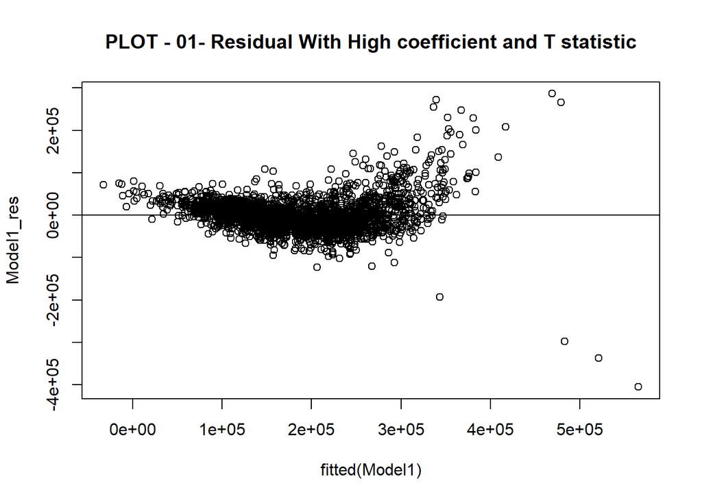

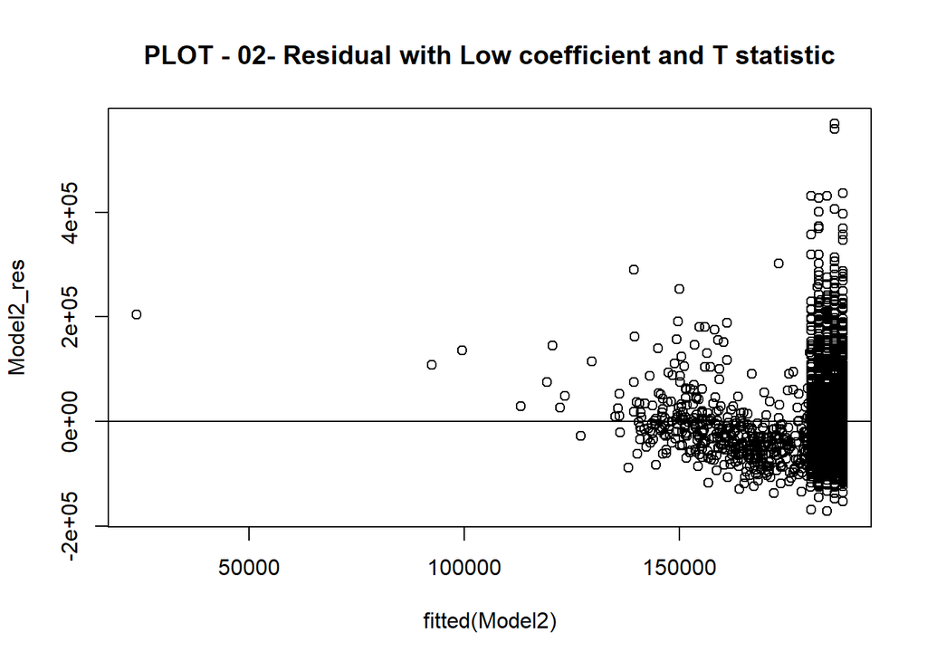

```r
Model1_res <- resid(Model1)
Model2_res <- resid(Model2)

plot(fitted(Model1), Model1_res) +
  abline(0,0)+
  title("PLOT - 01- Residual With High coefficient and T statistic")

plot(fitted(Model2), Model2_res) +
  abline(0,0)+
  title("PLOT - 02- Residual with Low coefficient and T statistic")
```

From PLOT -02, we can see that :

### Q-Q PLOT

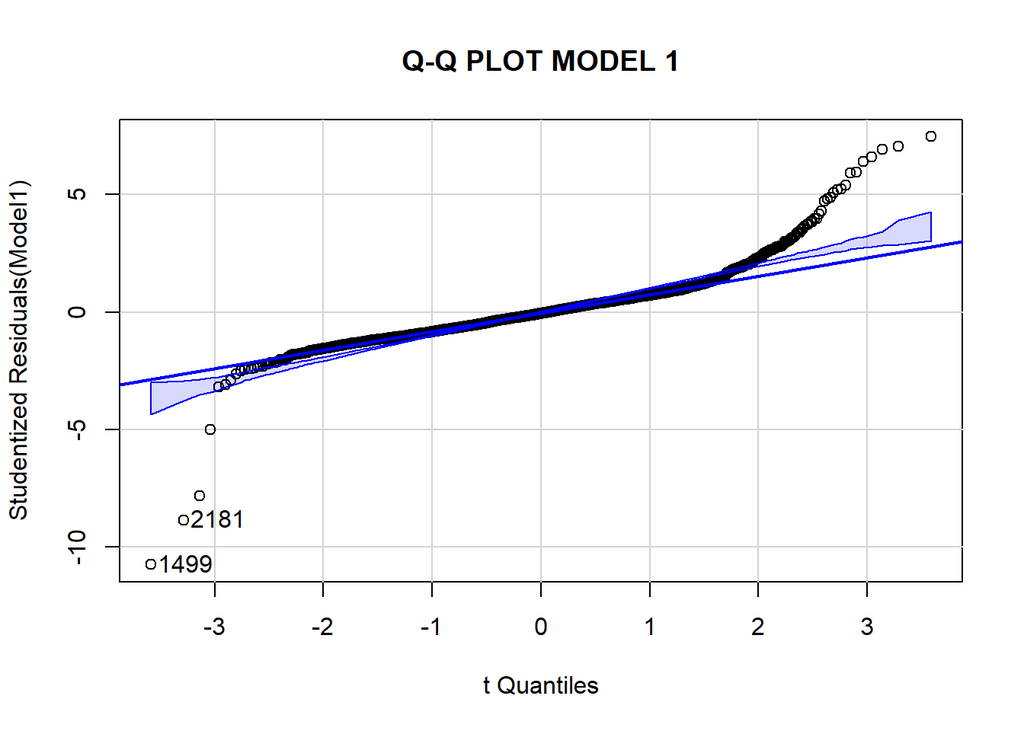

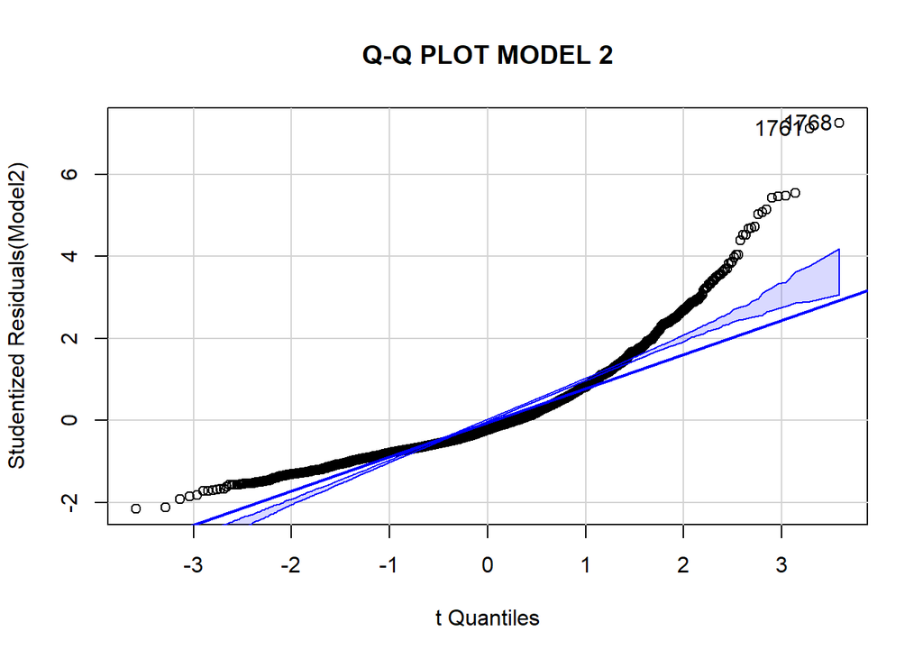

```r
qqPlot(Model1)+
  title("Q-Q PLOT MODEL 1")

qqPlot(Model2)+
  title("Q-Q PLOT MODEL 2")
```

Using Q-q plot we can learn about the observations that follows the normal line. The blue shade area shows observations that fall in 95% confidence interval. From plot of model 1 we can wee that most of the observation follow the normal line and there are less outliers From plot of model 2 we can see that most of the observation do not follow the normal line.

### OUTLIER

#### OUTLIER TEST MODEL 1

```r
outlierTest(Model1 , n=5)
```

```
         rstudent unadjusted p-value Bonferroni p
  1499 -10.739278         2.0554e-26   6.0223e-23
  2181  -8.845312         1.5466e-18   4.5314e-15
  2182  -7.801754         8.4301e-15   2.4700e-11
  1768   7.459692         1.1370e-13   3.3313e-10
  45     7.057208         2.1128e-12   6.1904e-09
```

The above table shows the top 5 outliers for model 1. The observation no 1499 have studentized residual of -10.73

#### OUTLIER TEST MODEL 2

```r
outlierTest(Model2,n=5)
```

```
       rstudent unadjusted p-value Bonferroni p
  1768 7.247077         5.4235e-13   1.5891e-09
  1761 7.117475         1.3771e-12   4.0348e-09
  2446 5.548659         3.1360e-08   9.1885e-05
  45   5.473423         4.7877e-08   1.4028e-04
  1064 5.466176         4.9855e-08   1.4607e-04
```

The above table shows the Top 5 outlier for model 2. The observation no 1768 have Studentized residual of +7.24

### MULTI COLLINEARITY

```r
## model 1
vif(Model1)
```

```
  Overall.Qual  Gr.Liv.Area   Year.Built   Fireplaces
      2.288653     1.663515     1.592690     1.306853
```

```r
## model 2
vif(Model2)
```

```
  Enclosed.Porch       Misc.Val        Yr.Sold
        1.000077       1.000151       1.000074
```

Multicollinearity help us to know if the predictor variables (independent) have correlation or not. If the value is below 5 we can say that there is not correlation between the Predictor variables. From the above multicollinearity test we can say that the model1 and model2 predictor variables have no correlation among them.

## REFERENCE

- » Interpreting Residual Plots to Improve Your Regression. (2021, April 12). Qualtrics. https://www.qualtrics.com/support/stats-iq/analyses/regression-guides/interpreting-residual-plots-improve-regression/
- Residual plots | Exploring bivariate numerical data | AP Statistics | Khan Academy. (2017, July 12). YouTube. https://www.youtube.com/watch?v=VamMrPZ-8fc
- Z. (2021, April 22). How to Create a Residual Plot in R. Statology. https://www.statology.org/residual-plot-r/
- Visualizing two variables - Characterizing bivariate relationships. (n.d.). DataCamp. https://campus.datacamp.com/courses/correlation-and-regression-in-r/visualizing-two-variables?ex=4